# Open Data Science course project

### 3. Summary measure analysis

It could be helpful in representing the data to summarize observations into their mean accompanied by standard error.

Summarizing the data

```r
# Time, baseline included
n <- RATSL$Time %>% unique() %>% length()

# Summary data with mean and standard error of RATSL by Group and Time
RATSS <- RATSL %>%
  group_by(Group, Time) %>%
  summarise( mean = mean(Weight), se = sd(Weight)/sqrt(n) ) %>%
  ungroup()

# Glimpse the data
glimpse(RATSS)
```

```
## Observations: 33
## Variables: 4
## $ Group <fct> 1, 1, 1, 1, 1, 1, 1, 1, 1, 1, 1, 2, 2, 2, 2, 2, 2, 2, 2,...
## $ Time  <int> 1, 8, 15, 22, 29, 36, 43, 44, 50, 57, 64, 1, 8, 15, 22, ...
## $ mean  <dbl> 250.625, 255.000, 254.375, 261.875, 264.625, 265.000, 26...
## $ se    <dbl> 4.589478, 3.947710, 3.460116, 4.100800, 3.333956, 3.5529...
```

Plotting the mean weights

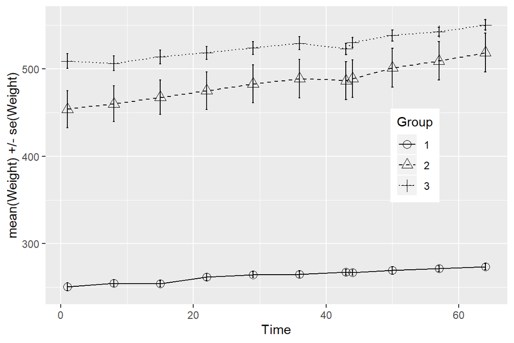

```r
ggplot(RATSS, aes(x = Time, y = mean, linetype = Group, shape = Group)) +
  geom_line() +
  scale_linetype_manual(values = c(1,2,3)) +
  geom_point(size=3) +
  scale_shape_manual(values = c(1,2,3)) +
  geom_errorbar(aes(ymin=mean-se, ymax=mean+se, linetype="1"), width=0.3) +
  theme(legend.position = c(0.8,0.5)) +
  scale_y_continuous(name = "mean(Weight) +/- se(Weight)")
```

Figure 3. Mean weights for the three groups in the RATS data

We notice that the three groups have distinctive weights development over time. Their confidence intervals do not overlap.

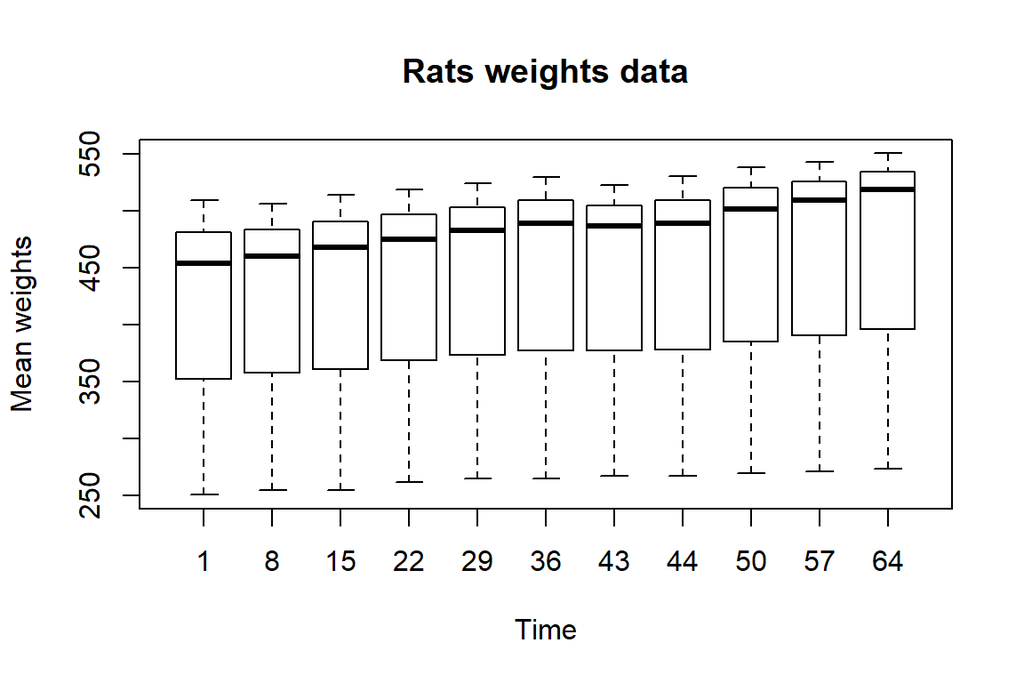

```r
boxplot(mean~Time,data=RATSS,main="Rats weights data",xlab="Time",ylab="Mean weights")
```

Figure 4. Boxplots for the times ofthe RATS data.

Applying a summary measure approach might help.

From figure 3 and the boxplot on figure 4, it looks like our data is of type Growth (Table 8.2 of MABS) where the eventual value of outcome is different between groups. The recommended summary measure approach is to use the percentage of change between first and last values.

As first values I will use the first quartile, and as last values, I will use the 3rd quartile.

As percentage of change between the lasts and the firsts, I will use the mean of the first quartile and the mean of the last quartile.

```r
# Create a summary data by treatment and subject with percentage of change between first and last values as the summary variable
RATSS2 <- RATSL %>%
  group_by(Group, ID) %>%
  summarise( diffperc= ((mean(Weight[Time>49]) /
                            mean(Weight[Time<16])
                            )-1)*100 ) %>%
  ungroup()

# Glimpse the data
glimpse(RATSS2)
```

```
## Observations: 16
## Variables: 3
## $ Group    <fct> 1, 1, 1, 1, 1, 1, 1, 1, 2, 2, 2, 2, 3, 3, 3, 3
## $ ID       <fct> 1, 2, 3, 4, 5, 6, 7, 8, 9, 10, 11, 12, 13, 14, 15, 16
## $ diffperc <dbl> 9.395973, 6.569343, 7.516779, 6.753247, 8.311688, 6.1...
```

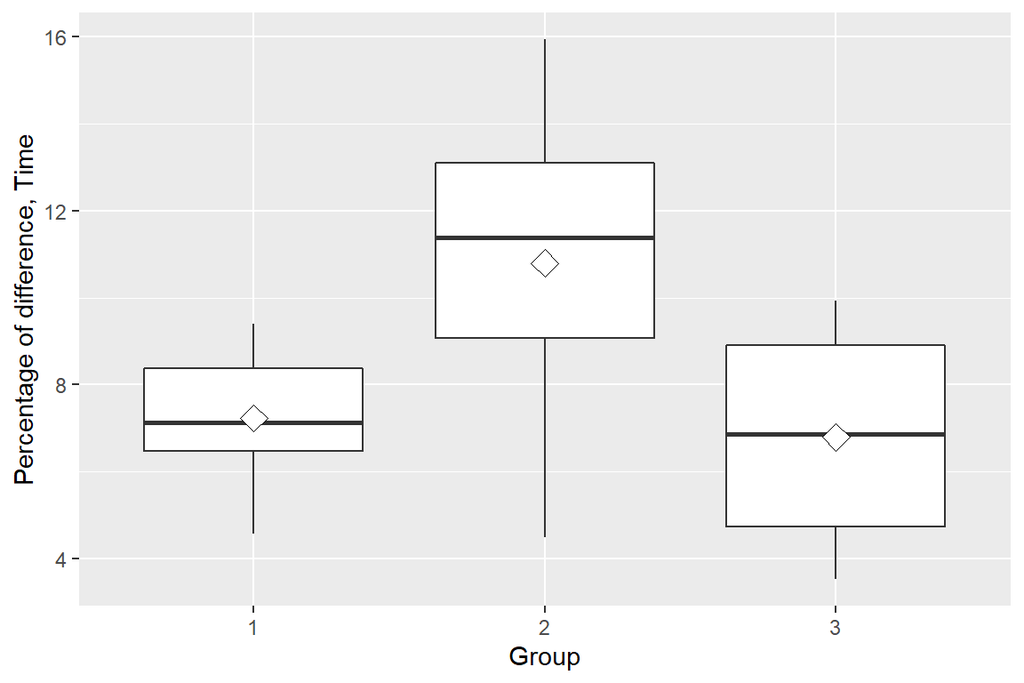

```r
# Draw a boxplot of the percentage of difference versus group
ggplot(RATSS2, aes(x = Group, y = diffperc)) +
  geom_boxplot() +
  stat_summary(fun.y = "mean", geom = "point", shape=23, size=4, fill = "white") +
  scale_y_continuous(name = "Percentage of difference, Time")
```

It seems that group 2 has the highest gain in weight with about 12% weight gain between the weight in the first quartile of time and the weight at the third quartile of time (percentage of difference between baseline and end-measures). However, the confidence intervals overlap, suggesting that differences between groups might not be statistically significant.

A statistical test might help evaluating the differences between groups.

A one way analysis of variances might be of help to test for differences between three groups.

```r
summary(aov(diffperc ~ Group, data = RATSS2))
```

```
##             Df Sum Sq Mean Sq F value Pr(>F)
## Group        2  41.79  20.893   2.442  0.126
## Residuals   13 111.25   8.557
```

It seems that, indeed, the groups do not differ significantly in terms of weight gain over time. (p-value = 0.126)

There is no need for incorporating baseline measurements as they are integrated in the calculation of the summary measure that we have chosen.

There are also no missing values to deal with.